# Latest_News_Classifier v_4

## 01. DATASET CREATION

The aim of this script is to create a dataset with the following information:

- Name of the article
- Content of the article
- Category of the article

## Fetching the Data

```python
pip install newsapi-python
```

```python
from newsapi import NewsApiClient
newsapi = NewsApiClient(api_key='798479ffe4544a0f9499eba44ef58915')
```

```python
import pandas as pd
sources = newsapi.get_sources(country='us',category = 'business', language = 'en')
list = []
# newsapi.get_everything
sources = sources['sources'] # getting the list of news portals with google
for i in sources:
  list.append(i['id']) # saving the id of each portals

print(list)

top_headlines = []
for i in list:
  top_headline = newsapi.get_top_headlines(sources=i,) # getting top headlines of each portal
  for j in top_headline['articles']:
    top_headlines.append(j)
print(top_headlines)

content = []
for i in top_headlines:
  content.append(i['title'] + " " + i['description'])  # getting titles of each news

print(content)

business_news = pd.DataFrame(content)
business_news.columns = ['content'] # saving all titles in dataframe
print(business_news)
business_news['category'] = 'business'
```

```
['bloomberg', 'business-insider', 'fortune', 'the-wall-street-journal']
[{'source': {'id': 'bloomberg', 'name': 'Bloomberg'}, 'author': None, 'title': "'Bad Guys' Repeats At No. 1, Liam Neeson's Latest Misfires", 'description': '', 'url': 'https://www.bloomberg.com/news/articles/2022-05-01/-bad-guys-repeats-at-no-1-liam-neeson-s-latest-misfires', 'urlToImage': None, 'pu…
["'Bad Guys' Repeats At No. 1, Liam Neeson's Latest Misfires ", "CityLab: The Week's Most Popular Stories ", 'Bored Ape Metaverse Frenzy Raises Millions, Crashes Ethereum (1) ', 'Kenya Raises Minimum Wage by 12% to Ease Impact of Inflation ', 'Germany Says Dependence on Russian Oil Could End in Late…
                                              content
0   'Bad Guys' Repeats At No. 1, Liam Neeson's Lat...
1           CityLab: The Week's Most Popular Stories
2   Bored Ape Metaverse Frenzy Raises Millions, Cr...
3   Kenya Raises Minimum Wage by 12% to Ease Impac...
4   Germany Says Dependence on Russian Oil Could E...
5   China Maintains Covid Fight as Virus Lockdowns...
6   One Reason for Warren Buffett's Success May No...
7   Swedish Premier Says Joining NATO Will Help Ba...
8   Speaker Nancy Pelosi Meets With Ukraine's Zele...
9   Motorcycles Rumble Through Canadian Capital Un...
10  MyPillow CEO Mike Lindell re-banned from Twitt...
```

[output cut: 29 more lines]

```python
sources = newsapi.get_sources(country='us',category = 'entertainment', language = 'en')
list = []
# newsapi.get_everything
sources = sources['sources'] # getting the list of news portals with google
for i in sources:
  list.append(i['id']) # saving the id of each portals

# print(list)

top_headlines = []
for i in list:
  top_headline = newsapi.get_top_headlines(sources=i,) # getting top headlines of each portal
  for j in top_headline['articles']:
    top_headlines.append(j)
# print(top_headlines)

content = []
for i in top_headlines:
  content.append("% s % s"%(i['title'],i['description']))  # getting titles of each news

print(content)

entertainment_news = pd.DataFrame(content)
entertainment_news.columns = ['content'] # saving all titles in dataframe
entertainment_news['category'] = 'entertainment'
print(entertainment_news)
```

```
['Your Intuition Can, Believe It Or Not, Reveal If You Think More With Your Head Or Heart — Try It Out If you automatically always choose left, you probably lead with your brain.', '43 Landlords Who Deserve To Be Publicly Shamed On The Internet I genuinely hope this post circulates in scammy landlor…
                                              content       category
0   Your Intuition Can, Believe It Or Not, Reveal ...  entertainment
1   43 Landlords Who Deserve To Be Publicly Shamed...  entertainment
2   Tell Us A Little About Yourself And We'll Matc...  entertainment
3   From "The Time Traveler's Wife" To "Top Gun: M...  entertainment
4   People Are Sharing The Disagreements About Kid...  entertainment
5   People Are Sharing The Shocking Secrets Their ...  entertainment
6   25 Things You Probably Need If You're A Plant ...  entertainment
7   19 Goodies To Buy Yourself For Mother’s Day If...  entertainment
8   22 Home Decor Products That'll Make You Love Y...  entertainment
9   WTF Is Happening Today? BuzzFeed Newsletters C...  entertainment
10  <em>Haunting of Bly Manor</em> creators bring ...  entertainment
11  <em>The Boulet Brothers' Dragula</em> season 4...  entertainment
12  Everything changes for <em>The Baby-Sitters Cl...  entertainment
```

[output cut: 39 more lines]

```python
sources = newsapi.get_sources(country='us',category = 'health', language = 'en')
list = []
# newsapi.get_everything
sources = sources['sources'] # getting the list of news portals with google
for i in sources:
  list.append(i['id']) # saving the id of each portals

# print(list)

top_headlines = []
for i in list:
  top_headline = newsapi.get_top_headlines(sources=i,) # getting top headlines of each portal
  for j in top_headline['articles']:
    top_headlines.append(j)
# print(top_headlines)

content = []
for i in top_headlines:
  content.append("% s % s"%(i['title'],i['description']))  # getting titles of each news

print(content)

health_news = pd.DataFrame(content)
health_news.columns = ['content'] # saving all titles in dataframe
print(health_news)

health_news['category'] = 'health'
```

```
['Synesthesia in a congenitally blind individual A new paper documents the first-ever known case of a congenitally blind person who has synesthesia.', 'Is breakfast really the most important meal of the day? Is it true that breakfast is the most important meal of the day? What will happen if you cho…
                                             content
0  Synesthesia in a congenitally blind individual...
1  Is breakfast really the most important meal of...
2  Benefits of dietary fiber may vary for differe...
3  LGBTQIA+ Asian Americans and Pacific Islanders...
4           Do humans possess 'nutritional wisdom'?
5  Hepatitis outbreak in children in US and Europ...
6  Valneva COVID-19 vaccine: What do we know abou...
7  In Conversation: Why climate change matters fo...
8  Changing how we heat our homes can benefit bot...
9  Help or hindrance: New calorie labeling rules ...
```

```python
sources = newsapi.get_sources(country='us',category = 'science', language = 'en')
list = []
# newsapi.get_everything
sources = sources['sources'] # getting the list of news portals with google
for i in sources:
  list.append(i['id']) # saving the id of each portals

# print(list)

top_headlines = []
for i in list:
  top_headline = newsapi.get_top_headlines(sources=i,) # getting top headlines of each portal
  for j in top_headline['articles']:
    top_headlines.append(j)
# print(top_headlines)

content = []
for i in top_headlines:
  content.append("% s % s"%(i['title'],i['description']))  # getting titles of each news

print(content)

science_news = pd.DataFrame(content)
science_news.columns = ['content'] # saving all titles in dataframe
print(science_news)

science_news['category'] = 'science'
```

```
['3-ton parts of Stonehenge may have been carried from earlier monuments Years of archaeological research now suggest that Neolithic Britons lugged massive elements of the iconic monument from far-flung reaches of the island.', 'Families are leading a new wave in Black travel. Here’s why For many pa…
                                              content
0   3-ton parts of Stonehenge may have been carrie...
1   Families are leading a new wave in Black trave...
2   Bonus Episode: In Conversation: Reframing Blac...
3   Why mapping Mars completely changed how we see...
4   How these feuding map-makers shaped our fascin...
5   Can robots help keep us safe? Automated machin...
6   U.S. has secured 200 million more doses of COV...
7   Go island-hopping in Palawan, the Philippines ...
8   A new sensation: recording and reproducing tas...
9   Episode 3: Why War Zones Need Science Too Unda...
10  Methane emissions from cows spotted from space...
11  Space test dummies will measure female radiati...
12  The US has a new plan to help tackle criminals...
```

[output cut: 17 more lines]

```python
sources = newsapi.get_sources(country='us',category = 'sports', language = 'en')
list = []
# newsapi.get_everything
sources = sources['sources'] # getting the list of news portals with google
for i in sources:
  list.append(i['id']) # saving the id of each portals

# print(list)

top_headlines = []
for i in list:
  top_headline = newsapi.get_top_headlines(sources=i,) # getting top headlines of each portal
  for j in top_headline['articles']:
    top_headlines.append(j)
# print(top_headlines)

content = []
for i in top_headlines:
  content.append("% s % s"%(i['title'],i['description']))  # getting titles of each news

print(content)

sports_news = pd.DataFrame(content)
sports_news.columns = ['content'] # saving all titles in dataframe
print(sports_news)

sports_news['category'] = 'sports'
```

```
["2022 NFL Draft Grades for Every Team A true evaluation of how a team did in the  NFL  draft can't start to happen until about two years from the event. But where's the fun in that?   Draft grades have a bad reputation...", "NFL Draft 2022: Reviewing This Year's Biggest Steals, Reaches and Surprise…
                                              content
0   2022 NFL Draft Grades for Every Team A true ev...
1   NFL Draft 2022: Reviewing This Year's Biggest ...
2   Predicting Biggest Buyers in 2022 NBA Free Age...
3   Teams That Improved the Most Through the 2022 ...
4   Trade Packages to Split Up Jazz Stars Rudy Gob...
5   MLB's Ball Controversy Could Define the 2022 S...
6   Duke's No. 1 Recruit Interview Dereck Lively s...
7   Jon Rahm hangs on to win Mexico Open for first...
8   Giannis Antetokounmpo's second career playoff ...
9   Boston Celtics 'hit in mouth', out-muscled by ...
10  Golden State Warriors' Draymond Green ejected ...
11  Los Angeles Angels star Shohei Ohtani removed ...
12  Rafael Nadal, Novak Djokovic slam Wimbledon ba...
```

[output cut: 43 more lines]

```python
sources = newsapi.get_sources(country='us',category = 'technology', language = 'en')
list = []
# newsapi.get_everything
sources = sources['sources'] # getting the list of news portals with google
for i in sources:
  list.append(i['id']) # saving the id of each portals

# print(list)

top_headlines = []
for i in list:
  top_headline = newsapi.get_top_headlines(sources=i,) # getting top headlines of each portal
  for j in top_headline['articles']:
    top_headlines.append(j)
# print(top_headlines)

content = []
for i in top_headlines:
  content.append("% s % s"%(i['title'],i['description']))  # getting titles of each news

print(content)

technology_news = pd.DataFrame(content)
technology_news.columns = ['content'] # saving all titles in dataframe
print(technology_news)

technology_news['category'] = 'technology'
```

```
['Scientists blast out Earth’s location with the hope of reaching aliens "These efforts are like building a big bonfire in the woods and hoping someone finds you."', "The weekend’s best deals: Beats, iPads, Samsung portable SSD, and more Dealmaster also has deals on Apple's MacBook, Withings ScanWat…
                                              content
0   Scientists blast out Earth’s location with the...
1   The weekend’s best deals: Beats, iPads, Samsun...
2   Every little bit helps: How to pick the least ...
3   Tasting Coca-Cola’s first “gamer” flavor—and t...
4   Review: Oura Ring 3 and Whoop 4.0 are 2 ambiti...
..                                                ...
91  Twitter Insiders Fear Elon Musk Heralds a Trol...
92  Meet the People Illustrating the Brutality of ...
93  Welcome to Janelle Monáe’s Dreamworld In her n...
94  4 Best Digital Picture Frames for Sharing Phot...
95  13 Best Air Purifiers (2022): HEPA, Portable, ...

[96 rows x 1 columns]
```

```python
news_content = pd.concat([business_news, entertainment_news, sports_news, science_news, health_news,technology_news])
```

```python
news_content.to_csv("news_content(04202022).csv")
```

## Exploratory Data Analysis

```python
import pandas as pd
news_content1 = pd.read_csv('news_content(03122022.csv')
news_content2 = pd.read_csv('news_content(03132022).csv')
news_content3 = pd.read_csv('news_content(03142022).csv')
news_content4 = pd.read_csv('news_content(03152022).csv')
news_content5 = pd.read_csv('news_content(03162022).csv')
news_content6 = pd.read_csv('news_content(03192022).csv')
news_content7 = pd.read_csv('news_content(03182022).csv')
news_content8 = pd.read_csv('news_content(03202022).csv')
news_content9 = pd.read_csv('news_content(03212022).csv')
news_content10 = pd.read_csv('news_content(03232022).csv')
news_content11 = pd.read_csv('news_content(03262022).csv')
news_content12 = pd.read_csv('news_content(03282022).csv')
news_content13 = pd.read_csv('news_content(03272022).csv')
news_content14 = pd.read_csv('news_content(03292022) (1).csv')
news_content15 = pd.read_csv('news_content(03302022).csv')
news_content16 = pd.read_csv('news_content(03312022).csv')
news_content17 = pd.read_csv('news_content(04012022).csv')
```

```python
news_content = pd.concat([news_content1,news_content2,news_content3, news_content4,news_content5, news_content6,news_content7,
                          news_content8,news_content9,news_content10,news_content11,news_content12,news_content13,news_content14,news_content15,
                          news_content16,news_content17])
```

```python
news_content.head()
```

|  | Unnamed: 0 | content | category |
| --- | --- | --- | --- |
| 0 | 0 | Platt's BlueCrest Aims to Lure Traders With 30... | business |
| 1 | 1 | What Do Companies Owe Working Mothers? | business |
| 2 | 2 | Banks Eye $6.6 Billion Debt for Orange, Masmov... | business |
| 3 | 3 | The World Younger Russians Knew Is Over | business |
| 4 | 4 | LME Battles to Restore Confidence Amid Hedge F... | business |

```python
import pandas as pd
import matplotlib.pyplot as plt
import pickle
import seaborn as sns
sns.set_style("whitegrid")
import altair as alt
#alt.renderers.enable("notebook")

# Code for hiding seaborn warnings
import warnings
warnings.filterwarnings("ignore")
```

```python
df = news_content
```

```python
df.head()
```

|  | Unnamed: 0 | content | category |
| --- | --- | --- | --- |
| 0 | 0 | Platt's BlueCrest Aims to Lure Traders With 30... | business |
| 1 | 1 | What Do Companies Owe Working Mothers? | business |
| 2 | 2 | Banks Eye $6.6 Billion Debt for Orange, Masmov... | business |
| 3 | 3 | The World Younger Russians Knew Is Over | business |
| 4 | 4 | LME Battles to Restore Confidence Amid Hedge F... | business |

```python
df.shape
```

```
(4778, 3)
```

### Number of articles in each category

```python
bars = alt.Chart(df).mark_bar(size=50).encode(
    x=alt.X("category"),
    y=alt.Y("count():Q", axis=alt.Axis(title='Number of articles')),
    tooltip=[alt.Tooltip('count()', title='Number of articles'), 'category'],
    color='category',
)

text = bars.mark_text(
    align='center',
    baseline='bottom',
).encode(
    text='count()'
)

(bars + text).interactive().properties(
    height=300,
    width=700,
    title = "Number of articles in each category",
)
```

[interactive chart not shown]

### % of articles in each category

```python
df['id'] = 1
df2 = pd.DataFrame(df.groupby('category').count()['id']).reset_index()

bars = alt.Chart(df2).mark_bar(size=50).encode(
    x=alt.X('category'),
    y=alt.Y('PercentOfTotal:Q', axis=alt.Axis(format='.0%', title='% of Articles')),
    color='category'
).transform_window(
    TotalArticles='sum(id)',
    frame=[None, None]
).transform_calculate(
    PercentOfTotal="datum.id / datum.TotalArticles"
)

text = bars.mark_text(
    align='center',
    baseline='bottom',
    #dx=5  # Nudges text to right so it doesn't appear on top of the bar
).encode(
    text=alt.Text('PercentOfTotal:Q', format='.1%')
)

(bars + text).interactive().properties(
    height=300,
    width=700,
    title = "% of articles in each category",
)
```

[interactive chart not shown]

### News length by category

Definition of news length field. Although there are special characters in the text (\r, \n), it will be useful as an approximation.

```python
# df.drop('id', inplace=True, axis=1)
df.drop('Unnamed: 0', inplace=True, axis=1)
```

```python
df
```

|  | content | category | id |
| --- | --- | --- | --- |
| 0 | Platt's BlueCrest Aims to Lure Traders With 30... | business | 1 |
| 1 | What Do Companies Owe Working Mothers? | business | 1 |
| 2 | Banks Eye $6.6 Billion Debt for Orange, Masmov... | business | 1 |
| 3 | The World Younger Russians Knew Is Over | business | 1 |
| 4 | LME Battles to Restore Confidence Amid Hedge F... | business | 1 |
| ... | ... | ... | ... |
| 277 | A Wave of Startups Is Tackling Cow Burps and O... | technology | 1 |
| 278 | 'A House Between Earth and the Moon' Book Revi... | technology | 1 |
| 279 | Russians Need VPNs. The Kremlin Hates Them VPN... | technology | 1 |
| 280 | 19 Reusable Products We Love (2022): Bags, Wat... | technology | 1 |
| 281 | 14 Best Wireless Earbuds (2022): Truly Wireles... | technology | 1 |

4778 rows × 3 columns

```python
df['News_length'] = df['content'].str.len()
```

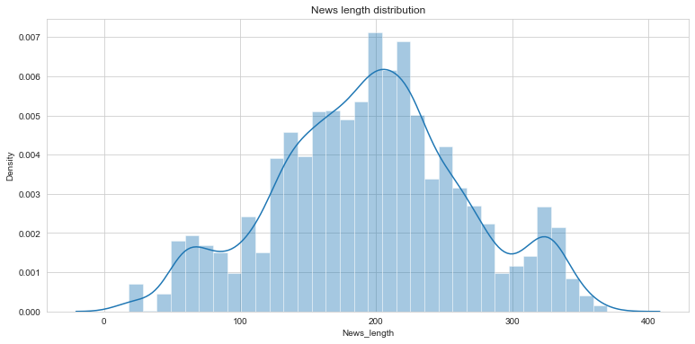

```python
plt.figure(figsize=(12.8,6))
sns.distplot(df['News_length']).set_title('News length distribution');
```

```python
df['News_length'].describe()
```

```
count    4778.000000
mean      195.410423
std        69.971710
min        18.000000
25%       150.000000
50%       197.000000
75%       238.000000
max       370.000000
Name: News_length, dtype: float64
```

```python
quantile_95 = df['News_length'].quantile(0.95)
df_95 = df[df['News_length'] < quantile_95]
```

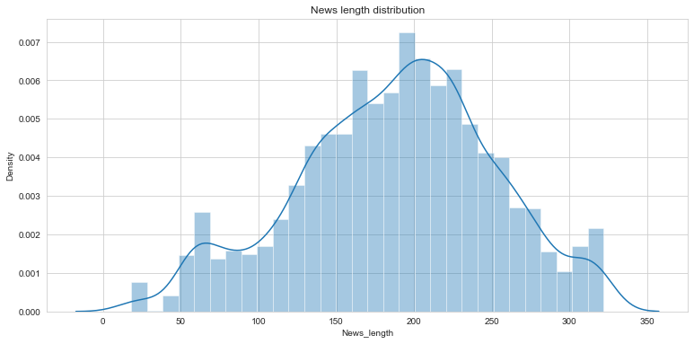

```python
plt.figure(figsize=(12.8,6))
sns.distplot(df_95['News_length']).set_title('News length distribution');
```

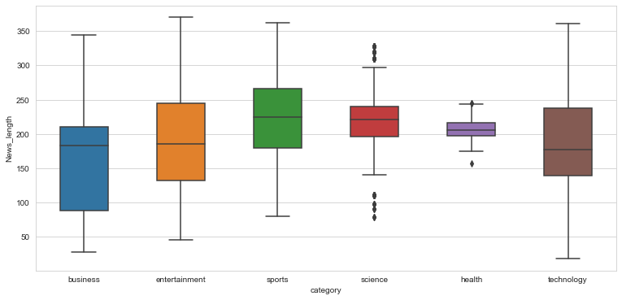

```python
plt.figure(figsize=(12.8,6))
sns.boxplot(data=df, x='category', y='News_length', width=.5);
```

Now, let's remove the larger documents for better comprehension:

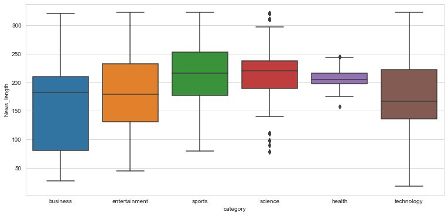

```python
plt.figure(figsize=(12.8,6))
sns.boxplot(data=df_95, x='category', y='News_length');
```

We can see that, although the length distribution is different for every category, the difference is not too big. If we had way too different lengths between categories we would have a problem since the feature creation process may take into account counts of words. However, when creating the features with TF-IDF scoring, we will normalize the features just to avoid this.

At this point, we cannot do further Exploratory Data Analysis. We'll turn onto the Feature Engineering section.

## Feature Engineering

The next step is to create features from the raw text so we can train the machine learning models. The steps followed are:

Text Cleaning and Preparation: cleaning of special characters, downcasing, punctuation signs. possessive pronouns and stop words removal and lemmatization. Label coding: creation of a dictionary to map each category to a code. Train-test split: to test the models on unseen data. Text representation: use of TF-IDF scores to represent text.

```python
import pickle
import pandas as pd
import re
import nltk
from nltk.corpus import stopwords
from nltk.stem import WordNetLemmatizer
from sklearn.feature_extraction.text import TfidfVectorizer
from sklearn.model_selection import train_test_split
from sklearn.feature_selection import chi2
import numpy as np
```

```python
df.head()
```

|  | content | category | id | News_length |
| --- | --- | --- | --- | --- |
| 0 | Platt's BlueCrest Aims to Lure Traders With 30... | business | 1 | 64 |
| 1 | What Do Companies Owe Working Mothers? | business | 1 | 39 |
| 2 | Banks Eye $6.6 Billion Debt for Orange, Masmov... | business | 1 | 63 |
| 3 | The World Younger Russians Knew Is Over | business | 1 | 40 |
| 4 | LME Battles to Restore Confidence Amid Hedge F... | business | 1 | 56 |

And visualize one sample news content:

```python
df.iloc[1]['content']
```

```
'What Do Companies Owe Working Mothers? '
```

## 1. Text cleaning and preparation

### 1. Text cleaning and preparation

We can see the following special characters:

1. \r
2. \n
3. \ before possessive pronouns (government's = government\'s)
4. \ before possessive pronouns 2 (Yukos' = Yukos\')
5. " when quoting text

```python
# \r and \n
df['Content_Parsed_1'] = df['content'].str.replace("\r", " ")
df['Content_Parsed_1'] = df['Content_Parsed_1'].str.replace("\n", " ")
df['Content_Parsed_1'] = df['Content_Parsed_1'].str.replace("    ", " ")
```

Regarding 3rd and 4th bullet, although it seems there is a special character, it won't affect us since it is not a real character:

```python
text = "Mr Greenspan\'s"
text
```

```
"Mr Greenspan's"
```

```python
# " when quoting text
df['Content_Parsed_1'] = df['Content_Parsed_1'].str.replace('"', '')
```

```python
df.head(50)
```

|  | content | category | id | News_length | Content_Parsed_1 |
| --- | --- | --- | --- | --- | --- |
| 0 | Platt's BlueCrest Aims to Lure Traders With 30... | business | 1 | 64 | Platt's BlueCrest Aims to Lure Traders With 30... |
| 1 | What Do Companies Owe Working Mothers? | business | 1 | 39 | What Do Companies Owe Working Mothers? |
| 2 | Banks Eye $6.6 Billion Debt for Orange, Masmov... | business | 1 | 63 | Banks Eye $6.6 Billion Debt for Orange, Masmov... |
| 3 | The World Younger Russians Knew Is Over | business | 1 | 40 | The World Younger Russians Knew Is Over |
| 4 | LME Battles to Restore Confidence Amid Hedge F... | business | 1 | 56 | LME Battles to Restore Confidence Amid Hedge F... |
| 5 | U.K Trade Deficit Widens to Most Since 1996 as... | business | 1 | 60 | U.K Trade Deficit Widens to Most Since 1996 as... |
| 6 | Japanese Megabanks Join SBI Holdings to Pull S... | business | 1 | 65 | Japanese Megabanks Join SBI Holdings to Pull S... |
| 7 | Russia's State-Owned Fleet of Oil Tankers Is C... | business | 1 | 68 | Russia's State-Owned Fleet of Oil Tankers Is C... |
| 8 | Dubai's Tecom Courts Investors After Lining Up... | business | 1 | 61 | Dubai's Tecom Courts Investors After Lining Up... |
| 9 | Oil Prices for Mar. 11, 2022: Brent Crude, WTI | business | 1 | 47 | Oil Prices for Mar. 11, 2022: Brent Crude, WTI |
| 10 | Biden: US will ban Russian seafood, vodka, dia... | business | 1 | 200 | Biden: US will ban Russian seafood, vodka, dia... |
| 11 | Billionaires made enough during pandemic to pa... | business | 1 | 220 | Billionaires made enough during pandemic to pa... |
| 12 | Investors pull a record $13.5 billion from Eur... | business | 1 | 173 | Investors pull a record $13.5 billion from Eur... |
| 13 | Ukraine claims to have killed a third top Russ... | business | 1 | 205 | Ukraine claims to have killed a third top Russ... |
| 14 | Congress' war profiteers have Lockheed Martin,... | business | 1 | 213 | Congress' war profiteers have Lockheed Martin,... |
| 15 | Video: Ukraine ambushes Russia tanks, missile ... | business | 1 | 212 | Video: Ukraine ambushes Russia tanks, missile ... |
| 16 | US and NATO sending missiles and other militar... | business | 1 | 189 | US and NATO sending missiles and other militar... |
| 17 | Russian oligarch's 2 yachts worth $1 billion h... | business | 1 | 221 | Russian oligarch's 2 yachts worth $1 billion h... |
| 18 | New Airbnb hosts earned the most in these 10 s... | business | 1 | 209 | New Airbnb hosts earned the most in these 10 s... |
| 19 | Russia's struggling military leaves Putin with... | business | 1 | 200 | Russia's struggling military leaves Putin with... |
| 20 | Corporate feminism has sold us a lie about wom... | business | 1 | 207 | Corporate feminism has sold us a lie about wom... |
| 21 | About 40% of new CEOs fail within 18 months. H... | business | 1 | 269 | About 40% of new CEOs fail within 18 months. H... |
| 22 | The American Rescue Plan saved the public sect... | business | 1 | 210 | The American Rescue Plan saved the public sect... |
| 23 | A cycling champ turned tech exec talks about t... | business | 1 | 141 | A cycling champ turned tech exec talks about t... |
| 24 | The imperative to redesign business is now gre... | business | 1 | 123 | The imperative to redesign business is now gre... |
| 25 | White House’s executive order for crypto is a ... | business | 1 | 135 | White House’s executive order for crypto is a ... |
| 26 | Ukraine’s cyber success prompts call for U.S. ... | business | 1 | 204 | Ukraine’s cyber success prompts call for U.S. ... |
| 27 | The media’s racial bias is also happening off ... | business | 1 | 167 | The media’s racial bias is also happening off ... |
| 28 | Honoring RBG’s legacy means protecting federal... | business | 1 | 199 | Honoring RBG’s legacy means protecting federal... |
| 29 | The ‘democratic enterprise’ will redefine our ... | business | 1 | 204 | The ‘democratic enterprise’ will redefine our ... |
| 30 | In the Rubble of Ukraine’s Second-Largest City... | business | 1 | 257 | In the Rubble of Ukraine’s Second-Largest City... |
| 31 | Biden Says U.S. Plans to Revoke Normal Trade R... | business | 1 | 142 | Biden Says U.S. Plans to Revoke Normal Trade R... |
| 32 | Pressure Mounts for Western Companies Leaving ... | business | 1 | 136 | Pressure Mounts for Western Companies Leaving ... |
| 33 | Tesla Set the Model for Selling EVs; Ford, VW ... | business | 1 | 183 | Tesla Set the Model for Selling EVs; Ford, VW ... |
| 34 | Iran Nuclear Talks Break Off Without a Deal Pa... | business | 1 | 117 | Iran Nuclear Talks Break Off Without a Deal Pa... |
| 35 | Russian Airstrikes Intensify in Western Ukrain... | business | 1 | 160 | Russian Airstrikes Intensify in Western Ukrain... |
| 36 | Aid Groups Rush Supplies to Ukraine as Medicin... | business | 1 | 164 | Aid Groups Rush Supplies to Ukraine as Medicin... |
| 37 | Biden, Democrats Lose Ground on Key Issues, WS... | business | 1 | 183 | Biden, Democrats Lose Ground on Key Issues, WS... |
| 38 | Google-Facebook Ad Deal Is Investigated by EU,... | business | 1 | 133 | Google-Facebook Ad Deal Is Investigated by EU,... |
| 39 | U.S. Stocks Open Higher After Putin Cites Prog... | business | 1 | 103 | U.S. Stocks Open Higher After Putin Cites Prog... |
| 40 | 20 Behind-The-Scenes Facts About Some Of The B... | entertainment | 1 | 148 | 20 Behind-The-Scenes Facts About Some Of The B... |
| 41 | 34 Screenshots That Prove Influencers Are Out ... | entertainment | 1 | 100 | 34 Screenshots That Prove Influencers Are Out ... |
| 42 | 28 Products That Are Majorly On Sale In Canada... | entertainment | 1 | 101 | 28 Products That Are Majorly On Sale In Canada... |
| 43 | 30 Onscreen Pairings That People Believe Have ... | entertainment | 1 | 157 | 30 Onscreen Pairings That People Believe Have ... |
| 44 | "I Suddenly Knew It Wasn't Worth It": People A... | entertainment | 1 | 283 | I Suddenly Knew It Wasn't Worth It: People Are... |
| 45 | People Are Sharing Their "Low Cost, Massive Im... | entertainment | 1 | 164 | People Are Sharing Their Low Cost, Massive Imp... |
| 46 | I Know This Is Kiiiiiinda Creepy, But The Wedd... | entertainment | 1 | 159 | I Know This Is Kiiiiiinda Creepy, But The Wedd... |
| 47 | Your Interior Decorating Skills Will Reveal Wh... | entertainment | 1 | 118 | Your Interior Decorating Skills Will Reveal Wh... |
| 48 | 27 Sexist Things Male Customers And Clients Ha... | entertainment | 1 | 149 | 27 Sexist Things Male Customers And Clients Ha... |
| 49 | WTF Is Happening Today? BuzzFeed Newsletters C... | entertainment | 1 | 59 | WTF Is Happening Today? BuzzFeed Newsletters C... |

### 1.2. Upcase/downcase

We'll downcase the texts because we want, for example, Football and football to be the same word.

```python
# Lowercasing the text
df['Content_Parsed_2'] = df['Content_Parsed_1'].str.lower()
```

### 1.3. Punctuation signs

Punctuation signs won't have any predicting power, so we'll just get rid of them.

```python
punctuation_signs = "?:!.,;"
df['Content_Parsed_3'] = df['Content_Parsed_2']

for punct_sign in punctuation_signs:
    df['Content_Parsed_3'] = df['Content_Parsed_3'].str.replace(punct_sign, '')
```

By doing this we are messing up with some numbers, but it's no problem since we aren't expecting any predicting power from them.

### 1.4. Possessive pronouns

We'll also remove possessive pronoun terminations:

```python
df['Content_Parsed_4'] = df['Content_Parsed_3'].str.replace("'s", "")
```

### 1.5. Stemming and Lemmatization

Since stemming can produce output words that don't exist, we'll only use a lemmatization process at this moment. Lemmatization takes into consideration the morphological analysis of the words and returns words that do exist, so it will be more useful for us.

```python
# Downloading punkt and wordnet from NLTK
nltk.download('punkt')
print("------------------------------------------------------------")
nltk.download('wordnet')
```

```
True
```

```python
# Saving the lemmatizer into an object
wordnet_lemmatizer = WordNetLemmatizer()
```

In order to lemmatize, we have to iterate through every word:

```python
df.iloc[2]['Content_Parsed_4']
```

```
'banks eye $66 billion debt for orange masmovil joint venture '
```

```python
df['Content_Parsed_4'].head()
```

```
0    platt bluecrest aims to lure traders with 30% ...
1               what do companies owe working mothers
2    banks eye $66 billion debt for orange masmovil...
3             the world younger russians knew is over
4    lme battles to restore confidence amid hedge f...
Name: Content_Parsed_4, dtype: object
```

```python
nrows = len(df)
lemmatized_text_list = []

for row in range(0, nrows):

    # Create an empty list containing lemmatized words
    lemmatized_list = []

    # Save the text and its words into an object
    text = df.iloc[row]['Content_Parsed_4']
    text_words = text.split(" ")

    # Iterate through every word to lemmatize
    for word in text_words:
        lemmatized_list.append(wordnet_lemmatizer.lemmatize(word, pos="v"))

    # Join the list
    lemmatized_text = " ".join(lemmatized_list)

    # Append to the list containing the texts
    lemmatized_text_list.append(lemmatized_text)
```

```python
df['Content_Parsed_5'] = lemmatized_text_list
```

Although lemmatization doesn't work perfectly in all cases (as can be seen in the example below), it can be useful.

### 1.6. Stop words

```python
# Downloading the stop words list
nltk.download('stopwords')
```

```
True
```

```python
# Loading the stop words in english
stop_words = stopwords.words('english')
```

```python
stop_words[0:10]
```

```
['i', 'me', 'my', 'myself', 'we', 'our', 'ours', 'ourselves', 'you', "you're"]
```

To remove the stop words, we'll handle a regular expression only detecting whole words, as seen in the following example:

```python
example = "me eating a meal"
word = "me"

# The regular expression is:
regex = r"\b" + word + r"\b"  # we need to build it like that to work properly

re.sub(regex, "StopWord", example)
```

```
'StopWord eating a meal'
```

We can now loop through all the stop words:

```python
df['Content_Parsed_6'] = df['Content_Parsed_5']

for stop_word in stop_words:

    regex_stopword = r"\b" + stop_word + r"\b"
    df['Content_Parsed_6'] = df['Content_Parsed_6'].str.replace(regex_stopword, '')
```

We have some dobule/triple spaces between words because of the replacements. However, it's not a problem because we'll tokenize by the spaces later.

As an example, we'll show an original news article and its modifications throughout the process:

```python
df.iloc[44]['content']
```

```
'"I Suddenly Knew It Wasn\'t Worth It": People Are Sharing The Moment They Realized They Had To Quit Their Job (And Quit Their Manager) "When I requested time off two weeks in advance for my stepson\'s doctor\'s appointment, my manager said, \'You know...he\'s not your biological child.\'"'
```

#### 1.Special character cleaning

```python
df.iloc[44]['Content_Parsed_1']
```

```
"I Suddenly Knew It Wasn't Worth It: People Are Sharing The Moment They Realized They Had To Quit Their Job (And Quit Their Manager) When I requested time off two weeks in advance for my stepson's doctor's appointment, my manager said, 'You know...he's not your biological child.'"
```

#### 1.Upcase/downcase

```python
df.iloc[44]['Content_Parsed_2']
```

```
"i suddenly knew it wasn't worth it: people are sharing the moment they realized they had to quit their job (and quit their manager) when i requested time off two weeks in advance for my stepson's doctor's appointment, my manager said, 'you know...he's not your biological child.'"
```

#### 1.Punctuation signs

```python
df.iloc[44]['Content_Parsed_3']
```

```
"i suddenly knew it wasn't worth it people are sharing the moment they realized they had to quit their job (and quit their manager) when i requested time off two weeks in advance for my stepson's doctor's appointment my manager said 'you knowhe's not your biological child'"
```

#### 1.Possessive pronouns

```python
df.iloc[44]['Content_Parsed_4']
```

```
"i suddenly knew it wasn't worth it people are sharing the moment they realized they had to quit their job (and quit their manager) when i requested time off two weeks in advance for my stepson doctor appointment my manager said 'you knowhe not your biological child'"
```

#### 1.Stemming and Lemmatization

```python
df.iloc[44]['Content_Parsed_5']
```

```
"i suddenly know it wasn't worth it people be share the moment they realize they have to quit their job (and quit their manager) when i request time off two weeks in advance for my stepson doctor appointment my manager say 'you knowhe not your biological child'"
```

#### 1.Stop words

```python
df.iloc[44]['Content_Parsed_6']
```

```
" suddenly know  ' worth  people  share  moment  realize    quit  job ( quit  manager)   request time  two weeks  advance   stepson doctor appointment  manager say ' knowhe   biological child'"
```

Finally, we can delete the intermediate columns:

```python
df.head(5)
```

|  | content | category | id | News_length | Content_Parsed_1 | Content_Parsed_2 | Content_Parsed_3 | Content_Parsed_4 | Content_Parsed_5 | Content_Parsed_6 |
| --- | --- | --- | --- | --- | --- | --- | --- | --- | --- | --- |
| 0 | Platt's BlueCrest Aims to Lure Traders With 30... | business | 1 | 64 | Platt's BlueCrest Aims to Lure Traders With 30... | platt's bluecrest aims to lure traders with 30... | platt's bluecrest aims to lure traders with 30... | platt bluecrest aims to lure traders with 30% ... | platt bluecrest aim to lure traders with 30% s... | platt bluecrest aim lure traders 30% share ... |
| 1 | What Do Companies Owe Working Mothers? | business | 1 | 39 | What Do Companies Owe Working Mothers? | what do companies owe working mothers? | what do companies owe working mothers | what do companies owe working mothers | what do company owe work mother | company owe work mother |
| 2 | Banks Eye $6.6 Billion Debt for Orange, Masmov... | business | 1 | 63 | Banks Eye $6.6 Billion Debt for Orange, Masmov... | banks eye $6.6 billion debt for orange, masmov... | banks eye $66 billion debt for orange masmovil... | banks eye $66 billion debt for orange masmovil... | bank eye $66 billion debt for orange masmovil ... | bank eye $66 billion debt orange masmovil joi... |
| 3 | The World Younger Russians Knew Is Over | business | 1 | 40 | The World Younger Russians Knew Is Over | the world younger russians knew is over | the world younger russians knew is over | the world younger russians knew is over | the world younger russians know be over | world younger russians know |
| 4 | LME Battles to Restore Confidence Amid Hedge F... | business | 1 | 56 | LME Battles to Restore Confidence Amid Hedge F... | lme battles to restore confidence amid hedge f... | lme battles to restore confidence amid hedge f... | lme battles to restore confidence amid hedge f... | lme battle to restore confidence amid hedge fu... | lme battle restore confidence amid hedge fund... |

```python
list_columns = [ "category", "content", "Content_Parsed_6"]
df = df[list_columns]

df = df.rename(columns={'Content_Parsed_6': 'Content_Parsed'})
```

```python
df.head()
```

|  | category | content | Content_Parsed |
| --- | --- | --- | --- |
| 0 | business | Platt's BlueCrest Aims to Lure Traders With 30... | platt bluecrest aim lure traders 30% share ... |
| 1 | business | What Do Companies Owe Working Mothers? | company owe work mother |
| 2 | business | Banks Eye $6.6 Billion Debt for Orange, Masmov... | bank eye $66 billion debt orange masmovil joi... |
| 3 | business | The World Younger Russians Knew Is Over | world younger russians know |
| 4 | business | LME Battles to Restore Confidence Amid Hedge F... | lme battle restore confidence amid hedge fund... |

#### IMPORTANT:

We need to remember that our model will gather the latest news articles from different newspapers every time we want. For that reason, we not only need to take into account the peculiarities of the training set articles, but also possible ones that are present in the gathered news articles.

For this reason, possible peculiarities have been studied in the 05. News Scraping folder.

## 2. Label coding

We'll create a dictionary with the label codification:

```python
category_codes = {
    'business': 0,
    'entertainment': 1,
    'science': 2,
    'sports': 3,
    'technology': 4,
    'health':5
}
```

```python
# Category mapping
df['Category_Code'] = df['category']
df = df.replace({'Category_Code':category_codes})
```

```python
df.head()
```

|  | category | content | Content_Parsed | Category_Code |
| --- | --- | --- | --- | --- |
| 0 | business | Platt's BlueCrest Aims to Lure Traders With 30... | platt bluecrest aim lure traders 30% share ... | 0 |
| 1 | business | What Do Companies Owe Working Mothers? | company owe work mother | 0 |
| 2 | business | Banks Eye $6.6 Billion Debt for Orange, Masmov... | bank eye $66 billion debt orange masmovil joi... | 0 |
| 3 | business | The World Younger Russians Knew Is Over | world younger russians know | 0 |
| 4 | business | LME Battles to Restore Confidence Amid Hedge F... | lme battle restore confidence amid hedge fund... | 0 |

## 3. Train - test split

We'll set apart a test set to prove the quality of our models. We'll do Cross Validation in the train set in order to tune the hyperparameters and then test performance on the unseen data of the test set.

```python
X_train, X_test, y_train, y_test = train_test_split(df['Content_Parsed'],
                                                    df['Category_Code'],
                                                    test_size=0.15,
                                                    random_state=8)
```

we'll choose a test set size of 15% of the full dataset.

### 4. Text representation

```python
# Parameter election
ngram_range = (1,2)
min_df = 10
max_df = 1.
max_features = 300
```

We have chosen these values as a first approximation.But it has to be mentioned that different combinations could be tried in order to improve even more the accuracy of the models.

For problems like Sentiment Analysis, setting n-gram ranges that use bigrams or trigrams can dramatically improve the accuracy of classification, as they can capture more complex expressions formed by the composition of more than one word. The rationale is that in Sentiment Analysis the outcome depends not only on the frequency of words but also on how they are combined: good has a different meaning alone than when preceded by a not as in not good.

```python
tfidf = TfidfVectorizer(encoding='utf-8',
                        ngram_range=ngram_range,
                        stop_words=None,
                        lowercase=False,
                        max_df=max_df,
                        min_df=min_df,
                        max_features=max_features,
                        norm='l2',
                        sublinear_tf=True)

features_train = tfidf.fit_transform(X_train).toarray()
labels_train = y_train
print(features_train.shape)

features_test = tfidf.transform(X_test).toarray()
labels_test = y_test
print(features_test.shape)
```

```
(4061, 300)
(717, 300)
```

We can use the Chi squared test in order to see what unigrams and bigrams are most correlated with each category:

```python
from sklearn.feature_selection import chi2
import numpy as np

for Product, category_id in sorted(category_codes.items()):
    features_chi2 = chi2(features_train, labels_train == category_id)
    indices = np.argsort(features_chi2[0])
    feature_names = np.array(tfidf.get_feature_names())[indices]
    unigrams = [v for v in feature_names if len(v.split(' ')) == 1]
    bigrams = [v for v in feature_names if len(v.split(' ')) == 2]
    print("# '{}' category:".format(Product))
    print("  . Most correlated unigrams:\n. {}".format('\n. '.join(unigrams[-5:])))
    print("  . Most correlated bigrams:\n. {}".format('\n. '.join(bigrams[-2:])))
    print("")
```

```
# 'business' category:
  . Most correlated unigrams:
. china
. ukrainian
. russian
. ukraine
. russia
  . Most correlated bigrams:
. russia ukraine
. ukraine war

# 'entertainment' category:
  . Most correlated unigrams:
. oscars
. baby
. trailer
. ign
. em
  . Most correlated bigrams:
. tv show
. covid 19

# 'health' category:
  . Most correlated unigrams:
. health
. 19
. research
. covid
. study
  . Most correlated bigrams:
. world cup
. covid 19

# 'science' category:
  . Most correlated unigrams:
. space
. episode
. map
. mar
. nextbigfuturecom
```

[output cut: 10 more lines]

```
. espncricinfocom
  . Most correlated bigrams:
. ncaa tournament
. world cup

# 'technology' category:
  . Most correlated unigrams:
. ccncom
. espncricinfocom
. apple
. none
. engadget
  . Most correlated bigrams:
. war ukraine
. get pay
```

```python
bigrams
```

```
['ukraine war',
 'russia ukraine',
 'covid 19',
 'tv show',
 'divisional round',
 'ncaa tournament',
 'world cup',
 'war ukraine',
 'get pay']
```

We can see there are only nine. This means the unigrams have more correlation with the category than the bigrams, and since we're restricting the number of features to the most representative 300, only a few bigrams are being considered.

# Model Training

Once we have our feature vectors built, we'll try several machine learning classification models in order to find which one performs best on our data. We will try with the following models:

- Random Forest
- K Nearest Neighbors
- Naïve Bayes
- Logistic Regression

The methodology used to train each model is as follows:

1. First of all, we will try all these classifier in base form.
2. Secondly, we'll define the metric we'll get when measuring the performance of a model. In this case, we'll use the accuracy.
3. After seeing the best fit model. we will improve the classifier using parameter tuning.
4. We'll perform a Randomized Search Cross Validation process in order to find the hyperparameter region in which we get higher values of accuracy.
5. Once we find that region, we'll use a Grid Search Cross Validation process to exhaustively find the best combination of hyperparameters.
6. Once we obtain the best combination of hyperparameters, we'll obtain the accuracy on the training data and the test data, the classification report and the confusion matrix.
7. Finally, we'll calculate the accuracy of a model with default hyperparameters, to see if we have achieved better results by hyperparameter tuning or not ?

```python
print(features_train.shape)
print(features_test.shape)
```

```
(4061, 300)
(717, 300)
```

```python
from pprint import pprint
from sklearn.model_selection import RandomizedSearchCV
from sklearn.model_selection import GridSearchCV
from sklearn.metrics import classification_report, confusion_matrix, accuracy_score
from sklearn.model_selection import ShuffleSplit
```

```python
from sklearn.ensemble import RandomForestClassifier
re = RandomForestClassifier()
re.fit(features_train,y_train)


from sklearn.neighbors import KNeighborsClassifier
cl = KNeighborsClassifier(n_neighbors=10)
cl.fit(features_train,y_train)


from sklearn.linear_model import LogisticRegression
lgm = LogisticRegression()
lgm.fit(features_train,y_train)


from sklearn.naive_bayes import GaussianNB
gn = GaussianNB()
gn.fit(features_train,y_train)
```

```
GaussianNB()
```

## Testing accuracies for all the classifiers

```python
rfc_pred = re.predict(features_train)
print('Training accuracy for Random Forest')
print(accuracy_score(labels_train, rfc_pred))

cl_pred = cl.predict(features_train)
print('Training accuracy for K Neighbors')
print(accuracy_score(labels_train, cl_pred))

lgm_pred = lgm.predict(features_train)
print('Training accuracy for linear regression')
print(accuracy_score(labels_train, lgm_pred))

gn_pred = gn.predict(features_train)
print('Training accuracy for naive bayes')
print(accuracy_score(labels_train, gn_pred))
```

```
Training accuracy for Random Forest
0.9908889436099483
Training accuracy for K Neighbors
0.7365180989903964
Training accuracy for linear regression
0.8468357547402118
Training accuracy for naive bayes
0.6067471066239842
```

### Cross-Validation for Hyperparameter tuning

First, we can see what hyperparameters the model has:

```python
rf_0 = RandomForestClassifier(random_state = 8)

print('Parameters currently in use:\n')
pprint(rf_0.get_params())
```

```
Parameters currently in use:

{'bootstrap': True,
 'ccp_alpha': 0.0,
 'class_weight': None,
 'criterion': 'gini',
 'max_depth': None,
 'max_features': 'auto',
 'max_leaf_nodes': None,
 'max_samples': None,
 'min_impurity_decrease': 0.0,
 'min_samples_leaf': 1,
 'min_samples_split': 2,
 'min_weight_fraction_leaf': 0.0,
 'n_estimators': 100,
 'n_jobs': None,
 'oob_score': False,
 'random_state': 8,
 'verbose': 0,
 'warm_start': False}
```

### Randomized Search Cross Validation

We first need to define the grid:

```python
# n_estimators
n_estimators = [int(x) for x in np.linspace(start = 50, stop = 200, num = 5)]

# max_features
max_features = ['auto', 'sqrt']

# random_state
random_state = [int(x) for x in np.linspace(5, 100, num = 5)]


# min_samples_split
min_samples_split = [1,2,4,6]

# min_samples_leaf
min_samples_leaf = [1, 2, 4]

# bootstrap
bootstrap = [True, False]

# Create the random grid
random_grid = {'n_estimators': n_estimators,
               'max_features': max_features,
               'random_state': random_state,
               'min_samples_split': min_samples_split,
               'min_samples_leaf': min_samples_leaf,
               'bootstrap': bootstrap}

pprint(random_grid)
```

```
{'bootstrap': [True, False],
 'max_features': ['auto', 'sqrt'],
 'min_samples_leaf': [1, 2, 4],
 'min_samples_split': [1, 2, 4, 6],
 'n_estimators': [50, 87, 125, 162, 200],
 'random_state': [5, 28, 52, 76, 100]}
```

```python
# First create the base model to tune
rfc = RandomForestClassifier(random_state=8)

# Definition of the random search
random_search = RandomizedSearchCV(estimator=rfc,
                                   param_distributions=random_grid,
                                   n_iter=25,
                                   scoring='accuracy',
                                   cv=3,
                                   verbose=1,
                                   random_state=8)

# Fit the random search model
random_search.fit(features_train, y_train)
```

```
Fitting 3 folds for each of 25 candidates, totalling 75 fits
```

```
RandomizedSearchCV(cv=3, estimator=RandomForestClassifier(random_state=8),
                   n_iter=25,
                   param_distributions={'bootstrap': [True, False],
                                        'max_features': ['auto', 'sqrt'],
                                        'min_samples_leaf': [1, 2, 4],
                                        'min_samples_split': [1, 2, 4, 6],
                                        'n_estimators': [50, 87, 125, 162, 200],
                                        'random_state': [5, 28, 52, 76, 100]},
                   random_state=8, scoring='accuracy', verbose=1)
```

```python
print("The best hyperparameters from Random Search are:")
print(random_search.best_params_)
print("")
print("The mean accuracy of a model with these hyperparameters is:")
print(random_search.best_score_)
```

```
The best hyperparameters from Random Search are:
{'random_state': 52, 'n_estimators': 200, 'min_samples_split': 6, 'min_samples_leaf': 1, 'max_features': 'auto', 'bootstrap': False}

The mean accuracy of a model with these hyperparameters is:
0.824426307241453
```

### Grid Search Cross Validation

```python
# Create the parameter grid based on the results of random search
bootstrap = [False]
max_features = ['auto']
min_samples_leaf = [0,1,2]
min_samples_split = [3,4,5]
n_estimators = [175,200,225]
random_state = [45,50,52,58]

param_grid = {
    'bootstrap': bootstrap,
    'max_features': max_features,
    'min_samples_leaf': min_samples_leaf,
    'min_samples_split': min_samples_split,
    'n_estimators': n_estimators,
    'random_state':random_state
}

# Create a base model
rfc = RandomForestClassifier()

# Manually create the splits in CV in order to be able to fix a random_state (GridSearchCV doesn't have that argument)
cv_sets = ShuffleSplit(n_splits = 3, test_size = .20)

# Instantiate the grid search model
grid_search = GridSearchCV(estimator=rfc,
                           param_grid=param_grid,
                           scoring='accuracy',
                           cv=cv_sets,
                           verbose=1)

# Fit the grid search to the data
grid_search.fit(features_train, labels_train)
```

```
Fitting 3 folds for each of 108 candidates, totalling 324 fits
```

```
GridSearchCV(cv=ShuffleSplit(n_splits=3, random_state=None, test_size=0.2, train_size=None),
             estimator=RandomForestClassifier(),
             param_grid={'bootstrap': [False], 'max_features': ['auto'],
                         'min_samples_leaf': [0, 1, 2],
                         'min_samples_split': [3, 4, 5],
                         'n_estimators': [175, 200, 225],
                         'random_state': [45, 50, 52, 58]},
             scoring='accuracy', verbose=1)
```

```python
print("The best hyperparameters from Grid Search are:")
print(grid_search.best_params_)
print("")
print("The mean accuracy of a model with these hyperparameters is:")
print(grid_search.best_score_)
```

```
The best hyperparameters from Grid Search are:
{'bootstrap': False, 'max_features': 'auto', 'min_samples_leaf': 1, 'min_samples_split': 4, 'n_estimators': 200, 'random_state': 52}

The mean accuracy of a model with these hyperparameters is:
0.8409184091840919
```

```python
best_rfc = random_search.best_estimator_   # random search cv
```

```python
best_rfc
```

```
RandomForestClassifier(bootstrap=False, min_samples_split=6, n_estimators=200,
                       random_state=52)
```

```python
best_rfc1 = grid_search.best_estimator_   # grid search cv
```

```python
best_rfc1
```

```
RandomForestClassifier(bootstrap=False, min_samples_split=4, n_estimators=200,
                       random_state=52)
```